# Real Estate Appraisal

## 0. Table of Contents

1. Imports and Settings
2. Load and Transform
3. Assignment of Independent Variables (X), Dependent Variables (y), examples (n), and features (k)
4. Assessed Property Data
5. Exploratory Data Analysis
6. Multiple Linear Regression Model with all variables (no regularization)
7. Removal of Variables with Lower Significance and New Linear Model
8. Regularized Multiple Linear Regression Model (α proportional to the P(t) of each variable)
9. Comparing Models

### 1. Imports and Settings

```python
import pandas as pd
import numpy as np
import matplotlib.pyplot as plt
import statsmodels.api as sm
plt.style.use('seaborn')
%matplotlib inline
```

### 2. Load and Transform

```python
df = pd.read_csv("../../data/sample.csv")
```

```python
df.head()
```

|  | address | neighborhood | total_value | area | Vap | rooms | restrooms | parking_slots | high_construction_std | low_construction_std | balcony | back | maids_room | condo_fee | floor | UV | source | agency | date_updated | link |
| --- | --- | --- | --- | --- | --- | --- | --- | --- | --- | --- | --- | --- | --- | --- | --- | --- | --- | --- | --- | --- |
| 0 | Rua Ererê | Cosme Velho | 1000000 | 120 | 3771.38 | 3 | 3 | 3 | 0 | 1 | 1 | 1 | 1 | 1308 | NaN | 8333.333333 | Zap | Kasanova | 01/11/2021 | https://www.zapimoveis.com.br/imovel/venda-apa... |
| 1 | Rua Filinto de Almeida | Cosme Velho | 700000 | 113 | 3295.39 | 2 | 2 | 0 | 0 | 1 | 1 | 1 | 1 | 1044 | 1.0 | 6194.690265 | Zap | OrlaRio | 01/11/2021 | https://www.zapimoveis.com.br/imovel/venda-apa... |
| 2 | Praça São Judas Tadeu, 6 | Cosme Velho | 965000 | 129 | 3771.38 | 3 | 4 | 2 | 0 | 1 | 1 | 1 | 1 | 1640 | NaN | 7480.620155 | Zap | João Correa | 01/11/2021 | https://www.zapimoveis.com.br/imovel/venda-apa... |
| 3 | Rua Cosme Velho, 315 | Cosme Velho | 880000 | 87 | 3795.13 | 2 | 2 | 1 | 0 | 0 | 0 | 0 | 1 | 900 | NaN | 10114.942529 | Zap | Calleri | NaN | https://www.zapimoveis.com.br/imovel/venda-apa... |
| 4 | Rua Marechal Pires Ferreira | Cosme Velho | 1870000 | 152 | 3980.89 | 4 | 3 | 2 | 1 | 0 | 1 | 1 | 1 | 1826 | NaN | 12302.631579 | Zap | Indik | NaN | https://www.zapimoveis.com.br/imovel/venda-apa... |

### 3. Assignment of Independent Variables (X), Dependent Variables (y), examples (n), and features (k)

```python
X = df.iloc[:, 3:14]
X = sm.add_constant(X).dropna()

ind = X.index

y = (df.loc[ind, 'total_value'] / df.loc[ind, 'area']).rename("unitary_value")

n = np.size(X, 0)
k = np.size(X, 1) - 1
```

```python
data = pd.concat([X, y], axis=1).drop(columns="const")
```

### 4. Assessed Property Data

```python
assessed_list = np.reshape([1, 100, 3795.13, 3, 2, 2, 0, 0, 1, 1, 1, 1340], (1, 12))
assessed = pd.DataFrame(assessed_list, index=[0], columns=X.columns)
assessed
```

|  | const | area | Vap | rooms | restrooms | parking_slots | high_construction_std | low_construction_std | balcony | back | maids_room | condo_fee |
| --- | --- | --- | --- | --- | --- | --- | --- | --- | --- | --- | --- | --- |
| 0 | 1.0 | 100.0 | 3795.13 | 3.0 | 2.0 | 2.0 | 0.0 | 0.0 | 1.0 | 1.0 | 1.0 | 1340.0 |

### 5. Exploratory Data Analysis

```python
X.describe()
```

|  | const | area | Vap | rooms | restrooms | parking_slots | high_construction_std | low_construction_std | balcony | back | maids_room | condo_fee |
| --- | --- | --- | --- | --- | --- | --- | --- | --- | --- | --- | --- | --- |
| count | 40.0 | 40.000000 | 40.000000 | 40.000000 | 40.00000 | 40.000000 | 40.000000 | 40.000000 | 40.000000 | 40.000000 | 40.000000 | 40.00000 |
| mean | 1.0 | 106.475000 | 3742.265250 | 2.600000 | 2.22500 | 1.400000 | 0.250000 | 0.200000 | 0.600000 | 0.800000 | 0.700000 | 1170.45000 |
| std | 0.0 | 35.142922 | 194.970066 | 0.708918 | 0.76753 | 0.928191 | 0.438529 | 0.405096 | 0.496139 | 0.405096 | 0.464095 | 562.86433 |
| min | 1.0 | 57.000000 | 3295.390000 | 2.000000 | 1.00000 | 0.000000 | 0.000000 | 0.000000 | 0.000000 | 0.000000 | 0.000000 | 402.00000 |
| 25% | 1.0 | 80.750000 | 3771.380000 | 2.000000 | 2.00000 | 1.000000 | 0.000000 | 0.000000 | 0.000000 | 1.000000 | 0.000000 | 875.00000 |
| 50% | 1.0 | 97.500000 | 3795.130000 | 2.000000 | 2.00000 | 1.000000 | 0.000000 | 0.000000 | 1.000000 | 1.000000 | 1.000000 | 1072.00000 |
| 75% | 1.0 | 124.000000 | 3795.130000 | 3.000000 | 3.00000 | 2.000000 | 0.250000 | 0.000000 | 1.000000 | 1.000000 | 1.000000 | 1432.00000 |
| max | 1.0 | 195.000000 | 3980.890000 | 4.000000 | 4.00000 | 3.000000 | 1.000000 | 1.000000 | 1.000000 | 1.000000 | 1.000000 | 3042.00000 |

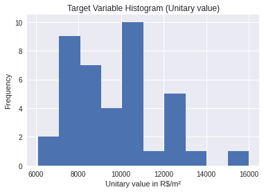

```python
plt.hist(y);
plt.title("Target Variable Histogram (Unitary value)");
plt.xlabel("Unitary value in R$/m²");
plt.ylabel("Frequency");
```

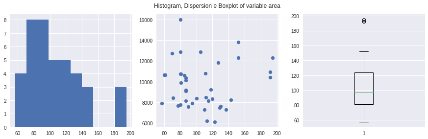

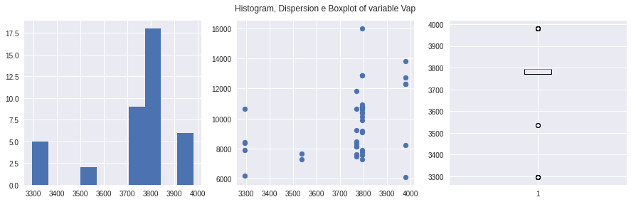

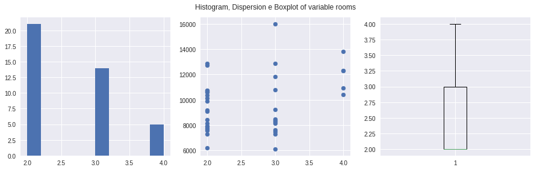

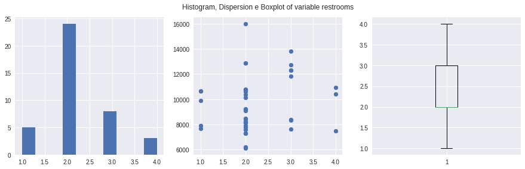

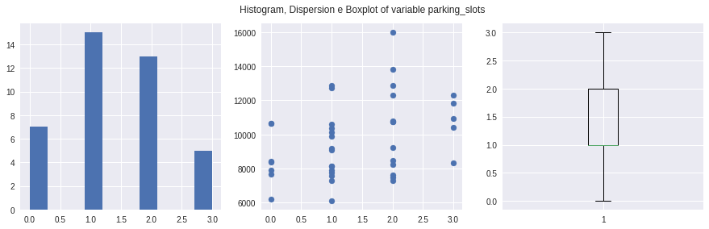

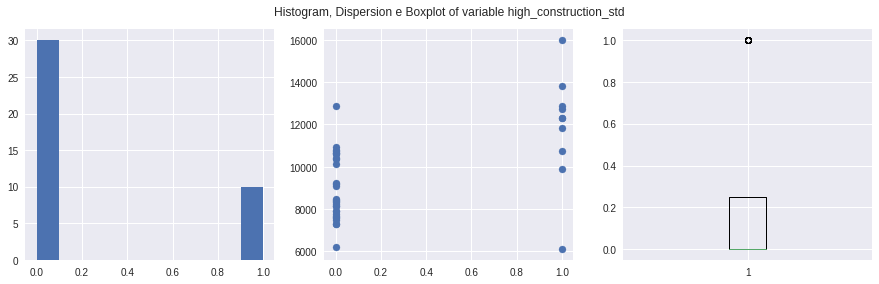

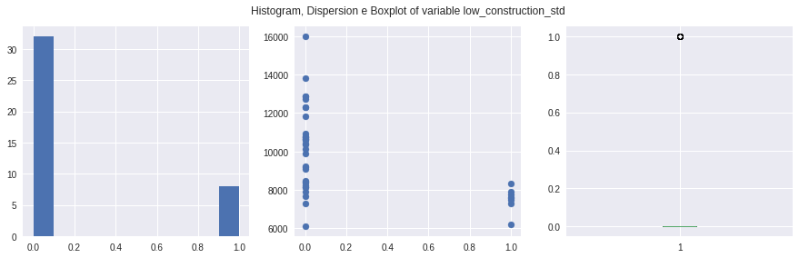

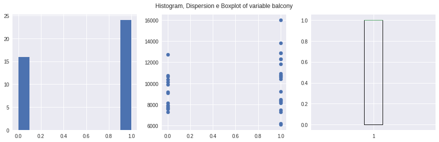

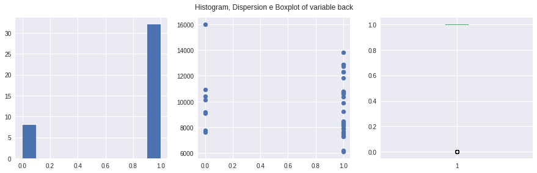

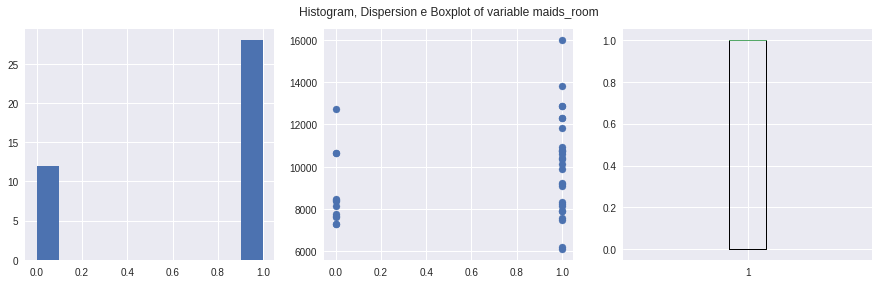

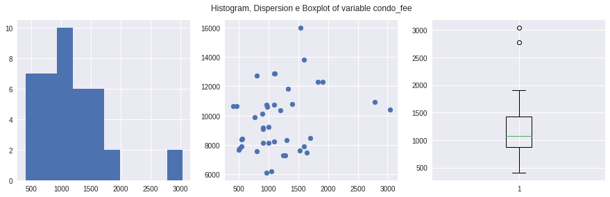

```python
for i in range(k):
    fig, axs = plt.subplots(1, 3, figsize=(12, 4))

    axs[0].hist(X[X.columns[i+1]])
    axs[1].scatter(X[X.columns[i+1]], y)
    axs[2].boxplot(X[X.columns[i+1]])

    fig.suptitle(f"Histogram, Dispersion e Boxplot of variable {X.columns[i+1]}")

    fig.subplots_adjust(left=.01, right=.99, bottom=.1, top=.9,
                        wspace=.2, hspace=.4)
```

#### Correlation Matrix:

```python
data.corr()
```

|  | area | Vap | rooms | restrooms | parking_slots | high_construction_std | low_construction_std | balcony | back | maids_room | condo_fee | unitary_value |
| --- | --- | --- | --- | --- | --- | --- | --- | --- | --- | --- | --- | --- |
| area | 1.000000 | 0.375628 | 0.885734 | 0.739313 | 0.717209 | 0.168459 | -0.041065 | 0.496474 | -0.149852 | 0.243209 | 0.834706 | 0.066196 |
| Vap | 0.375628 | 1.000000 | 0.339578 | 0.322457 | 0.618526 | 0.429959 | -0.210309 | -0.053612 | -0.129588 | 0.365774 | 0.397530 | 0.359944 |
| rooms | 0.885734 | 0.339578 | 1.000000 | 0.688014 | 0.678034 | 0.329914 | -0.160714 | 0.626953 | -0.107143 | 0.171457 | 0.750176 | 0.295788 |
| restrooms | 0.739313 | 0.322457 | 0.688014 | 1.000000 | 0.662248 | 0.133315 | 0.098961 | 0.377072 | -0.263896 | 0.194355 | 0.745638 | 0.167560 |
| parking_slots | 0.717209 | 0.618526 | 0.678034 | 0.662248 | 1.000000 | 0.314970 | -0.013639 | 0.356348 | -0.190941 | 0.404762 | 0.770430 | 0.354633 |
| high_construction_std | 0.168459 | 0.429959 | 0.329914 | 0.133315 | 0.314970 | 1.000000 | -0.288675 | 0.117851 | 0.144338 | 0.251976 | 0.115463 | 0.573402 |
| low_construction_std | -0.041065 | -0.210309 | -0.160714 | 0.098961 | -0.013639 | -0.288675 | 1.000000 | -0.229640 | -0.062500 | -0.081832 | -0.082496 | -0.493579 |
| balcony | 0.496474 | -0.053612 | 0.626953 | 0.377072 | 0.356348 | 0.117851 | -0.229640 | 1.000000 | 0.229640 | 0.133631 | 0.389144 | 0.239133 |
| back | -0.149852 | -0.129588 | -0.107143 | -0.263896 | -0.190941 | 0.144338 | -0.062500 | 0.229640 | 1.000000 | -0.054554 | -0.309968 | -0.105658 |
| maids_room | 0.243209 | 0.365774 | 0.171457 | 0.194355 | 0.404762 | 0.251976 | -0.081832 | 0.133631 | -0.054554 | 1.000000 | 0.344082 | 0.274013 |
| condo_fee | 0.834706 | 0.397530 | 0.750176 | 0.745638 | 0.770430 | 0.115463 | -0.082496 | 0.389144 | -0.309968 | 0.344082 | 1.000000 | 0.260613 |
| unitary_value | 0.066196 | 0.359944 | 0.295788 | 0.167560 | 0.354633 | 0.573402 | -0.493579 | 0.239133 | -0.105658 | 0.274013 | 0.260613 | 1.000000 |

#### Dispersion Matrix:

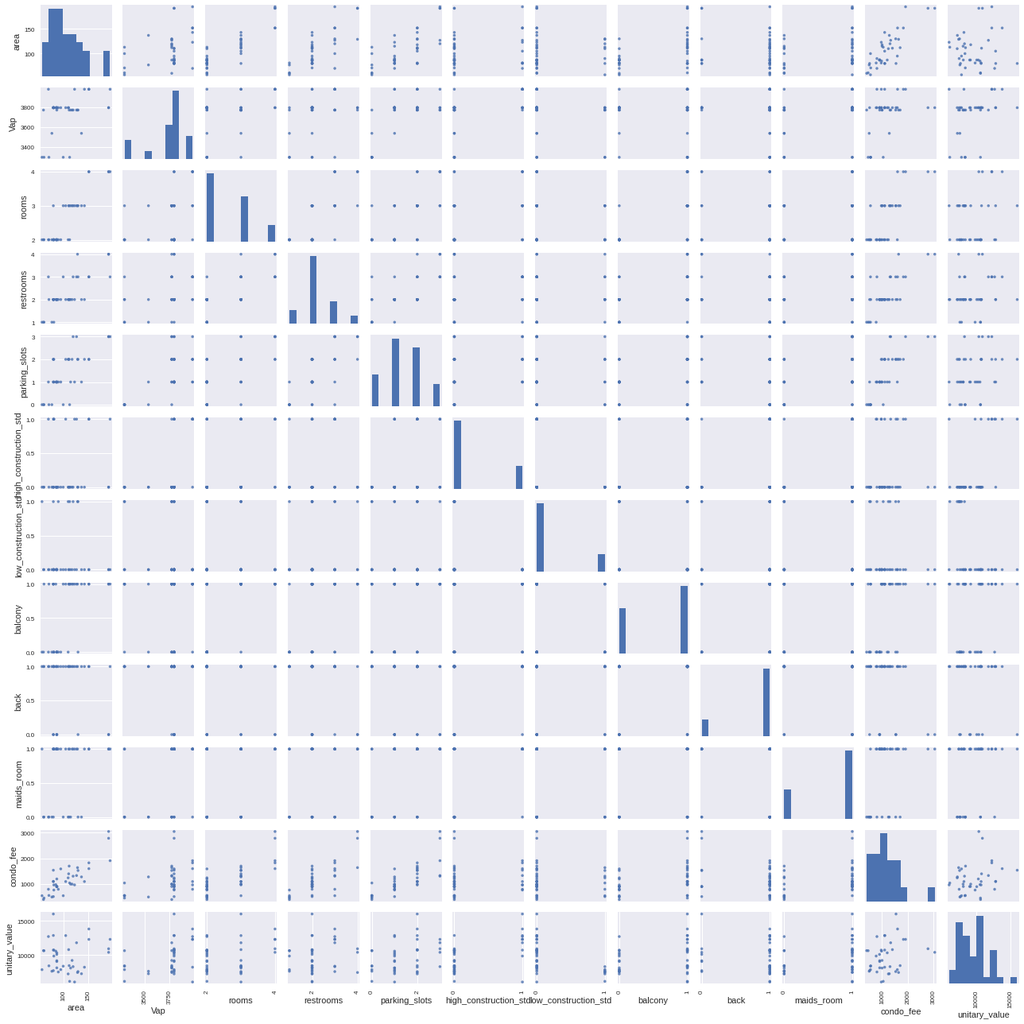

```python
pd.plotting.scatter_matrix(data, alpha=0.8, figsize=(18, 18));
plt.tight_layout()
```

#### Observations:

The graphic analysis of the histograms, dispersions, and boxplots of the independent variables shows an important degree of unbalance in the sample data, most of which do not present normal distribution behavior in their histograms, do not present constant variance and normality of errors in their dispersions with the dependent variable.

### 6. Multiple Linear Regression Model with all variables (no regularization)

```python
model = sm.OLS(y, X)
results = model.fit()
results.summary()
```

OLS Regression Results

| Dep. Variable: | unitary_value | R-squared: | 0.687 |
| --- | --- | --- | --- |
| Model: | OLS | Adj. R-squared: | 0.564 |
| Method: | Least Squares | F-statistic: | 5.585 |
| Date: | Thu, 18 Feb 2021 | Prob (F-statistic): | 0.000112 |
| Time: | 12:57:00 | Log-Likelihood: | -341.23 |
| No. Observations: | 40 | AIC: | 706.5 |
| Df Residuals: | 28 | BIC: | 726.7 |
| Df Model: | 11 |  |  |
| Covariance Type: | nonrobust |  |  |

|  | coef | std err | t | P>\|t\| | [0.025 | 0.975] |
| --- | --- | --- | --- | --- | --- | --- |
| const | 8159.5739 | 6894.359 | 1.184 | 0.247 | -5962.881 | 2.23e+04 |
| area | -67.2940 | 18.823 | -3.575 | 0.001 | -105.850 | -28.738 |
| Vap | 0.4746 | 1.899 | 0.250 | 0.805 | -3.416 | 4.365 |
| rooms | 1445.5949 | 956.240 | 1.512 | 0.142 | -513.174 | 3404.364 |
| restrooms | 238.2090 | 519.062 | 0.459 | 0.650 | -825.041 | 1301.459 |
| parking_slots | 525.2464 | 529.898 | 0.991 | 0.330 | -560.201 | 1610.694 |
| high_construction_std | 1821.5949 | 717.857 | 2.538 | 0.017 | 351.131 | 3292.059 |
| low_construction_std | -1622.9112 | 708.091 | -2.292 | 0.030 | -3073.370 | -172.453 |
| balcony | 607.9504 | 782.704 | 0.777 | 0.444 | -995.347 | 2211.247 |
| back | -704.2597 | 702.000 | -1.003 | 0.324 | -2142.241 | 733.722 |
| maids_room | 308.6252 | 602.470 | 0.512 | 0.612 | -925.479 | 1542.730 |
| condo_fee | 1.4806 | 0.982 | 1.508 | 0.143 | -0.531 | 3.492 |

| Omnibus: | 12.729 | Durbin-Watson: | 1.929 |
| --- | --- | --- | --- |
| Prob(Omnibus): | 0.002 | Jarque-Bera (JB): | 19.940 |
| Skew: | -0.797 | Prob(JB): | 4.68e-05 |
| Kurtosis: | 6.070 | Cond. No. | 1.17e+05 |

Notes:  
[1] Standard Errors assume that the covariance matrix of the errors is correctly specified.  
[2] The condition number is large, 1.17e+05. This might indicate that there are  
strong multicollinearity or other numerical problems.

```python
assessed_UV_01 = sum(results.params*assessed.loc[0])
assessed_TV_01 = assessed_UV_01 * assessed.loc[0, 'area']
print(f"The property value estimated by the Nonregularized Multiple\nLinear Regression Model with all variables is:\nR$ {assessed_TV_01:,.2f}.")
```

```
The property value estimated by the Nonregularized Multiple
Linear Regression Model with all variables is:
R$ 1,129,140.39.
```

#### P>|t| or Student's t-test

t indicates the probability, assuming the null hypothesis (bi = 0), of being an extreme sample. Therefore, this metric allows one to assume the significance of an explanatory variable for the model in the Confidence Interval of 1 - t.

### 7. Removal of Variables with Lower Significance and New Linear Model

```python
X.drop(columns=["Vap", "restrooms", "balcony", "back", "maids_room"], inplace=True)
assessed.drop(columns=["Vap", "restrooms", "balcony", "back", "maids_room"], inplace=True)
k = np.size(X, 1) - 1
```

```python
model = sm.OLS(y, X)
results = model.fit()
results.summary()
```

OLS Regression Results

| Dep. Variable: | unitary_value | R-squared: | 0.665 |
| --- | --- | --- | --- |
| Model: | OLS | Adj. R-squared: | 0.604 |
| Method: | Least Squares | F-statistic: | 10.91 |
| Date: | Thu, 18 Feb 2021 | Prob (F-statistic): | 1.11e-06 |
| Time: | 12:57:00 | Log-Likelihood: | -342.59 |
| No. Observations: | 40 | AIC: | 699.2 |
| Df Residuals: | 33 | BIC: | 711.0 |
| Df Model: | 6 |  |  |
| Covariance Type: | nonrobust |  |  |

|  | coef | std err | t | P>\|t\| | [0.025 | 0.975] |
| --- | --- | --- | --- | --- | --- | --- |
| const | 9293.4628 | 950.956 | 9.773 | 0.000 | 7358.728 | 1.12e+04 |
| area | -69.3888 | 17.207 | -4.033 | 0.000 | -104.397 | -34.380 |
| rooms | 1741.2516 | 752.641 | 2.314 | 0.027 | 209.992 | 3272.511 |
| parking_slots | 695.3719 | 418.640 | 1.661 | 0.106 | -156.358 | 1547.102 |
| high_construction_std | 1720.5988 | 616.493 | 2.791 | 0.009 | 466.335 | 2974.863 |
| low_construction_std | -1689.2336 | 599.272 | -2.819 | 0.008 | -2908.462 | -470.005 |
| condo_fee | 1.8602 | 0.838 | 2.219 | 0.033 | 0.155 | 3.566 |

| Omnibus: | 7.778 | Durbin-Watson: | 1.780 |
| --- | --- | --- | --- |
| Prob(Omnibus): | 0.020 | Jarque-Bera (JB): | 7.819 |
| Skew: | -0.636 | Prob(JB): | 0.0200 |
| Kurtosis: | 4.753 | Cond. No. | 6.55e+03 |

Notes:  
[1] Standard Errors assume that the covariance matrix of the errors is correctly specified.  
[2] The condition number is large, 6.55e+03. This might indicate that there are  
strong multicollinearity or other numerical problems.

```python
assessed_UV_02 = sum(results.params*assessed.loc[0])
assessed_TV_02 = assessed_UV_02 * assessed.loc[0, 'area']
print(f"The property value estimated by the Regularized Multiple Linear Regression\nModel with only variables significant to the model (at 89.4% CI) is:\nR$ {assessed_TV_02:,.2f}.")
```

[output not shown]

### 8. Regularized Multiple Linear Regression Model (α proportional to the P(t) of each variable)

```python
alpha = [0, 0, 10, 30, 0, 0, 10]
```

```python
model = sm.OLS(y, X)

results_reg = model.fit_regularized(method='elastic_net', alpha=alpha, L1_wt=1.0,
                                start_params=None, profile_scale=False, refit=False)
results_reg.params
```

```
const                    8801.898697
area                      -38.899948
rooms                    1115.493518
parking_slots             599.961575
high_construction_std    1852.828842
low_construction_std    -1782.580705
condo_fee                   0.992578
dtype: float64
```

```python
assessed_UV_03 = sum(results.params*assessed.loc[0])
assessed_TV_03 = assessed_UV_03 * assessed.loc[0, 'area']
print(f"The property value estimated by the Regularized Multiple Linear Regression\nModel by vector α and with only variables significant to the model (at 89.4% CI) is:\nR$ {assessed_TV_03:,.2f}.")
```

[output not shown]

```python
SSE = np.sum((np.dot(X, results_reg.params) - y).pow(2))
SST = np.sum((np.mean(y) - y).pow(2))
R2 = 1 - SSE/SST
R2
```

```
0.6284833473929141
```

```python
R2_Aj = 1 - (1 - R2)*((n - 1)/(n - k - 1))
R2_Aj
```

```
0.5609348651007167
```

### 9. Comparing Models

[output not shown]